# Two Variables: Qualitative

Author

Orville D. Hombrebueno

Published

December 1, 2024

# The Data

```r
# load packages
library(tidyverse)
library(knitr)
library(gtsummary)
library(ggstatsplot)
library(downlit)
library(broom)

# load the data
titanic <- ggstatsplot::Titanic_full |>
  mutate(
    Class = factor(Class)
  )
```

## The Titanic Data Set

The `Titanic_full` data set of the {ggstatsplot} package is a data frame with 2201 rows and 5 variables.

- `id` Dummy identity number for each person.
- `Class` 1st, 2nd, 3rd, Crew.
- `Sex` Male, Female.
- `Age` Child, Adult.
- `Survived` No, Yes.

This data set provides information on the fate of passengers on the fatal maiden voyage of the ocean liner Titanic, summarized according to economic status (class), sex, age and survival.

The first 6 rows of the titanic data set is shown in Table 1.

```r
titanic |>
  head() |> # getting the first six rows of the data
  kable() # creating a table
```

Table 1: The first 6 observations of the data set.

| id | Class | Sex | Age | Survived |
| --- | --- | --- | --- | --- |
| 1 | 3rd | Male | Child | No |
| 2 | 3rd | Male | Child | No |
| 3 | 3rd | Male | Child | No |
| 4 | 3rd | Male | Child | No |
| 5 | 3rd | Male | Child | No |
| 6 | 3rd | Male | Child | No |

## Descriptive Statistics

The frequency distribution of `Survived` when grouped according to `Sex` is shown in Table 2. Most of the passengers are male. The majority of female passengers survived, whereas the majority of male passengers did not.

```r
titanic |>
  tbl_summary(
    by = Sex,
    include = Survived
  )
```

Table 2: Summary statistics of `Survived` when grouped according to `Sex`.

| **Characteristic** | **Female** N = 470<sup>1</sup> | **Male** N = 1,731<sup>1</sup> |
| --- | --- | --- |
| Survived | 344 (73%) | 367 (21%) |

<sup>1</sup> n (%)

# Hypothesis Testing

## Research Question

Does a passenger’s sex affect their survival status?

## Hypothesis and Test Statistics

- $H_0:p_{Survived}-p_{Sex}=0$; passenger’s sex does not affect their survival status.
- $H_a:p_{Survived}-p_{Sex}\ne0$; passenger’s sex affects their survival status.
- Significance level, $\alpha=5\%$.
- **Pearson’s $\chi^2$-test of independence**
- Independence.
- Expected counts: all expected counts are $\ge5$ (see Table 3).

```r
# Create contingency table
observed <- table(titanic$Survived, titanic$Sex)

# Perform chi-squared test
chi_test <- chisq.test(observed)

# Extract the expected counts
expected <- chi_test$expected

# View expected counts
expected |>
  as_tibble() |>
  mutate(
    " " = c("No", "Yes")
  ) |>
  relocate(" ", .before = 1) |>
  mutate(across(where(is.numeric), ~ round(.x, 2))) |>
  kable()
```

Table 3: Expected counts.

|  | Female | Male |
| --- | --- | --- |
| No | 318.17 | 1171.83 |
| Yes | 151.83 | 559.17 |

## Results and Interpretation

The bar chart and test statistics is shown on Figure 1.

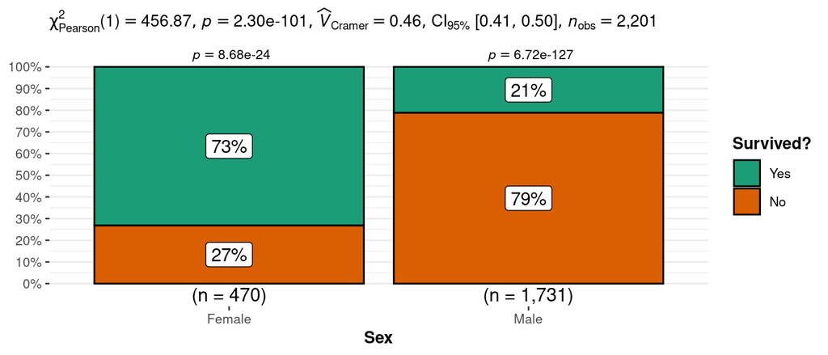

```r
ggbarstats(
  data = titanic,
  x = Survived,
  y = Sex,
  bf.message = FALSE,
  legend.title = "Survived?"
)
```